University of Edinburgh · Introduction to Data Science

# Student dropout warnings

How accurate are they,  
and who gets missed?

Before first-term grades arrive, who might a university reach out to?

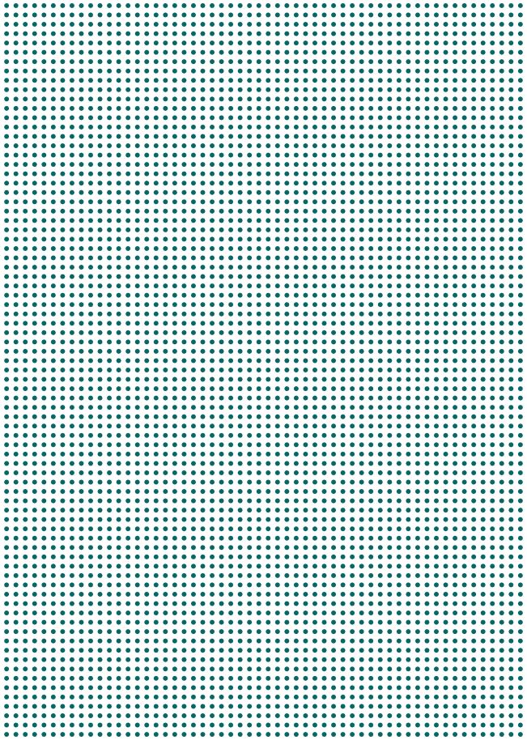

4,424 records · one dot per record

**Strong Tiger**  
Tiger · Harry · Reiyume · yingcheLiu

UCI Machine Learning Repository, dataset 697

The outcome

# What counts as a dropout?

4,424

student records from one Portuguese institution

A change of course or institution can count as **Dropout**.

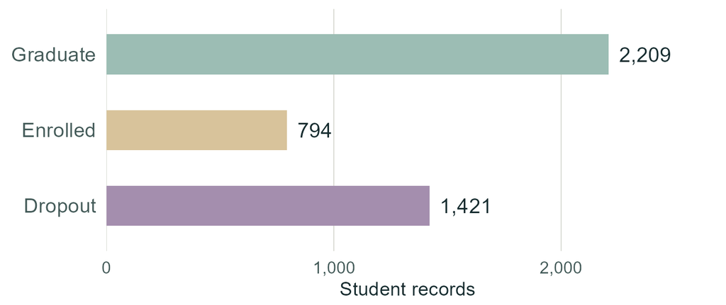

Status at the normal course endpoint, usually three years (four for Nursing). Enrolled means still studying at that endpoint.

Training data · 2,652 students

# The groups overlap at enrolment

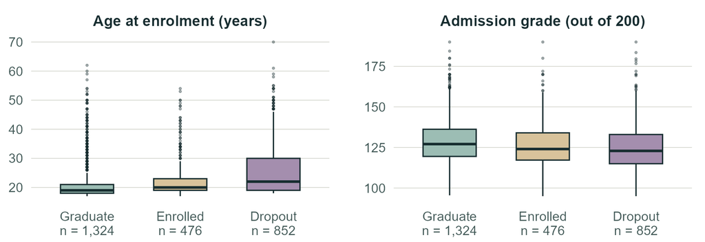

Median age was 22 for the dropout group and 19 for graduates. Admission grades overlapped too.

The line inside each box is the median. Quiz 7 led us to [Data to Viz](https://www.data-to-viz.com/caveat/boxplot.html); group sizes are printed beneath each box.

Enrolment-time prediction

# From enrolment records to a warning score

A logistic model combines age, admission grade and course to estimate the probability of recorded dropout.

Training

**2,652**

Fit the model.

Validation

**883**

Choose the cutoff.

Test

**889**

Evaluate the fixed rule.

Later, on training folds: mean AUC rose from **0.668** to **0.702** with course included.

Course is categorical. Semester grades were unavailable at enrolment; recorded gender was reserved for the audit.

Choosing a rule · validation only

# Why draw the line at 0.31?

0.31

Warn at or above this score.

Catch at least 70% of validation dropouts, then minimise false warnings.

**200 / 284** students with recorded dropout flagged in validation (70.4%).

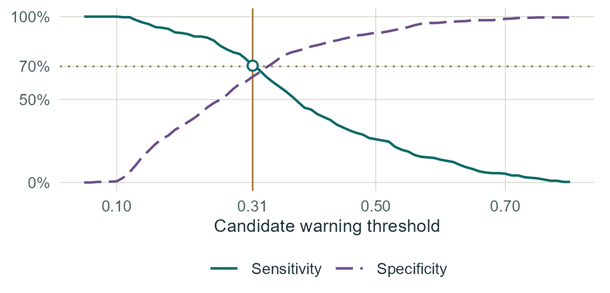

Our illustrative support target. We compared thresholds from 0.05 to 0.80 in steps of 0.01.

Held-out test set · 889 students · cutoff 0.31

# Who received a warning on the test set?

**409**students received a warning

**187**of those warnings matched a recorded dropout

**98**students with recorded dropout received no warning

**What if we warned nobody?**

Of the 889 test students, 604 had no recorded dropout. Predicting that outcome for everyone would be right 67.9% of the time and miss all 285 students with recorded dropout.

The test set contained 285 students with recorded dropout. The cutoff was chosen earlier on the separate validation set.

Two cutoffs · same test students and scores

# More students reached, more follow-up

| Cutoff | Recorded dropouts found | False warnings |
| --- | --- | --- |
| 0.50 | 80 | 45 |
| 0.31 | 187 | 222 |

At 0.31 we found **107 more** dropout records and issued **177 more** false warnings.

**Could advisers follow up?** If staff can handle 284 extra check-ins in a group this size, the lower cutoff may be worthwhile.

A false warning flags a student with no recorded dropout by the endpoint. Both cutoffs use the same test scores.

Recorded gender · 285 test students with a dropout record

# Who did the rule miss?

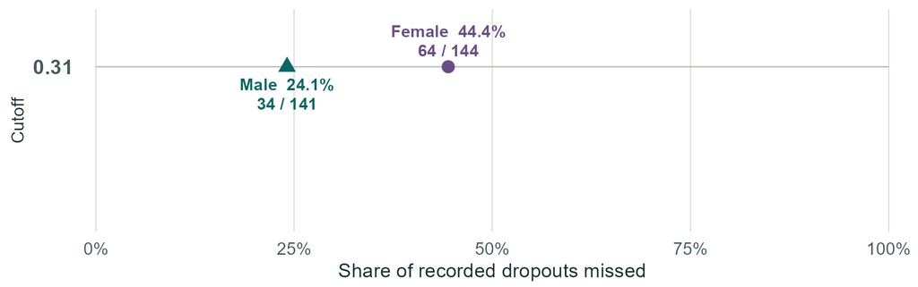

Female minus male: **20.3 percentage points**

95% bootstrap interval for this difference: 9.5 to 30.7 percentage points.

5,000 resamples within each recorded-gender group. The fitted model and cutoff stayed fixed.

Same students · the higher cutoff added for comparison

# A smaller gap can mean more missed students

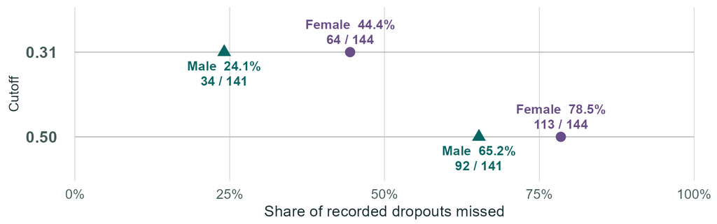

Gap: 20.3 → **13.2 percentage points** · Total missed: 98 → **205 students**

These are two previously evaluated rules. The primary cutoff remains 0.31, chosen on the validation set.

What the evidence can support

# What a university could do next

Offer a conversation

Let a person check the record and ask what support would help.

Plan for the workload

The primary rule flagged 409 of 889 test students.

Test the next cohort

Check who is missed locally and evaluate the effect of outreach.

One institution and historical enrolments. These data measure recorded outcomes; the effect of offering support needs its own evaluation.

Strong Tiger · Introduction to Data Science

# Sources and acknowledgements

Data and definitions

Realinho and colleagues. [UCI dataset 697](https://doi.org/10.24432/C5MC89) (CC BY 4.0) and the [original data paper](https://doi.org/10.3390/data7110146).

Group error criteria: [Fairness and Machine Learning](https://fairmlbook.org/classification.html) and the IDS Algorithmic Bias lecture.

Models and figures

IDS modelling, uncertainty and cross-validation lectures; [Lab 08](https://uoeids.github.io/labs/lab-08/lab-08.html) on ROC curves.

Quiz 7 prompted our review of [boxplots](https://www.data-to-viz.com/caveat/boxplot.html) and [interval labels](https://www.data-to-viz.com/caveat/error_bar.html) in Data to Viz.

ChatGPT/Codex assisted with code and text drafts, explanations, source checks, slide production and AI-generated campus illustrations in earlier drafts. Details and responsibilities are recorded in the report.

[Project repository](https://github.com/Tigershengsheng/ids-project) · R source, data, analysis and full references